# Bioinformatics Analysis and Visualisation of Medical Genomics Data

KI course number 5633, March 2023

Luuk Harbers

2023-03-10

## Task 1 - Literature

Answer the following questions:

**1. What is the medically relevant insight from the article?**

The authors identified how insulin-regulated genes, pathways and Transcription Factors respond to changes in body weight. They observe that the transcription response in human White Adipose Tissue (WAT) is selective. Furthermore, they observe that the insulin response in WAT remains present in severely Obese Women (OB). Concluding that the supressive effects of insulin are attenuated, the stimulatory effects remain largely intact.

**2. Which genomics technology/technologies were used?**

The genomics technology used in this paper is CAGE.

Further related research questions:

**3. List and explain at least three questions/ hypotheses you can think of that extend the analysis presented in the paper.**

Three potential questions/hypotheses are:

1. Besides the gene enrichment analysis, One could also look at the network of genes that are upregulated/downregulated in the different conditions directly. It would be interesting to see how networks of the altered genes look like, whether in these networks you would also see three clearly distinct groups or whether these are more tightly connected.
2. It would also be interesting to see if genes that are implicated in either of the identified groups of differentially expressed genes have different usages of transcription start sites compared to background genes.
3. The authors mentioned that they collected samples relatively soon after the clamp procedure to ensure they do not measure the Secondary effects. However, it would be interesting to also look at the secondary effects if it were possible to collect an additional (slightly later) sample.

## Task 4 - R basic operations

1. What is the square root of 10?

`sqrt(10)` = 3.1622777

2. What is the logarithm of 32 to the base 2?

`log2(32)` = 5

3. What is the sum of the numbers from 1 to 1000?

`sum(1:1000)` = 500500

4. What is the sum of all even numbers from 2 to 1000?

`sum(seq(2, 1000, 2))` = 250500

5. How many pairwise comparisons are there for 100 genes?

`100 * (100 - 1) / 2` = 4950

6. And how many ways to arrange 100 genes in triples?

`factorial(100) / factorial(100-3)` = 970200

## Task 5 - Using R example datasets

1. Use the R internal CO2 dataset (“data(CO2)”).

```r
# Load in data
data(CO2)
```

2. Describe briefly the content of the CO2 dataset using the help function.

```r
# Show the help output in Rstudio (or base R)
help(CO2)
```

The help function shows that CO2 is a data frame with 84 rows and 5 columns of daata from an experiment on the cold tolerance of the grass species Echinochloa crus-galli.

3. What is the average and median CO2 uptake of the plants from Quebec and Mississippi?

```r
# Calculate mean
mean_qb = mean(CO2[CO2$Type == "Quebec", "uptake"])
mean_ms = mean(CO2[CO2$Type == "Mississippi", "uptake"])

# Print results
paste0("The mean uptake of plans in Quebec is: ", mean_qb)
```

```
## [1] "The mean uptake of plans in Quebec is: 33.5428571428571"
```

```r
paste0("The mean uptake of plans in Mississippi is: ", mean_ms)
```

```
## [1] "The mean uptake of plans in Mississippi is: 20.8833333333333"
```

```r
# Calculate median
median_qb = median(CO2[CO2$Type == "Quebec", "uptake"])
median_ms = median(CO2[CO2$Type == "Mississippi", "uptake"])

# Print results
paste0("The median uptake of plants in Quebec is: ", median_qb)
```

```
## [1] "The median uptake of plants in Quebec is: 37.15"
```

```r
paste0("The median uptake of plants in Mississippi is: ", median_qb)
```

[output not shown]

```r
# Load the airway library or install it if it's not present
if (!require(airway)) BiocManager::install("airway")

# Load in airway data
data("airway")

# Check what kind of data airway is
head(airway)
```

```
## class: RangedSummarizedExperiment
## dim: 6 8
## metadata(1): ''
## assays(1): counts
## rownames(6): ENSG00000000003 ENSG00000000005 ... ENSG00000000460
##   ENSG00000000938
## rowData names(0):
## colnames(8): SRR1039508 SRR1039509 ... SRR1039520 SRR1039521
## colData names(9): SampleName cell ... Sample BioSample
```

```r
# See that it is a RangedSummarizedExperiment so check the assays
assays(airway)
```

```
## List of length 1
## names(1): counts
```

```r
# Get gene count data and transform it to data.table
counts = assays(airway)$counts

# Count the number of genes expressed per sample
colSums(counts > 0)
```

```
## SRR1039508 SRR1039509 SRR1039512 SRR1039513 SRR1039516 SRR1039517 SRR1039520
##      24633      24527      25699      23124      25508      25998      24662
## SRR1039521
##      23991
```

## Task 6 - R functions

1. Write a function that calculates the ratio of the mean and the median of a given vector. This is a helpful measure to detect data with outlying values. Note: See Reference for R language

```r
# Function to calculate the ratio of mean / median of a vector
calcRatio = function(vec) {
  return(mean(vec) / median(vec))
}
```

2. Write a function that ignores the lowest and the highest value from a given vector and calculate the mean.

```r
# Function to calculate the mean of a vector without the highest and lowest value
calcAdjMean = function(vec) {
  vec = sort(vec) # Sort vector
  vec = vec[c(-1, -length(vec))] # Remove first and last value
  return(mean(vec)) # Return mean
}
```

3. Read about piping from here:https://r4ds.had.co.nz/pipes.html#pipes (you don’t have to learn everything, a basic understanding of the usage is enough). Write a short (max. 300 characters, no spaces) explanation of why, how, and when not to use pipes.

One of the major advantages of piping is that it can make your code look easier to read and easier to interpret. When you want to chain functions you can use the pipe operator `%>%` (or `|>` in base R). However, you should not use pipes for (very) long sequences, multiple inputs/outputs or for complex relationships between the operations.

4. Familiarize yourself with the apply-family of functions (apply, lapply, sapply etc.) http://uc-r.github.io/apply_family Write a short explanation (max. 300 characters, no spaces) of why they could be useful in your work.

the apply-family can be very useful if you want to perform some type of operation over multiple columns/rows in a data.frame. Or, for me personally, you can use `lapply()` or `sapply()` when performing some function(s) over a list of patient samples. These can also easily be parallelized using `mcapply()`.

## Task 7 - Basic visualization with R

1. Compare the distributions of the body heights of the two species from the ‘magic_guys.csv’ dataset graphically

```r
require(data.table) # Load data.table
mguys = fread("~/Downloads/magic_guys.csv") # Load in dataset
```

[output not shown]

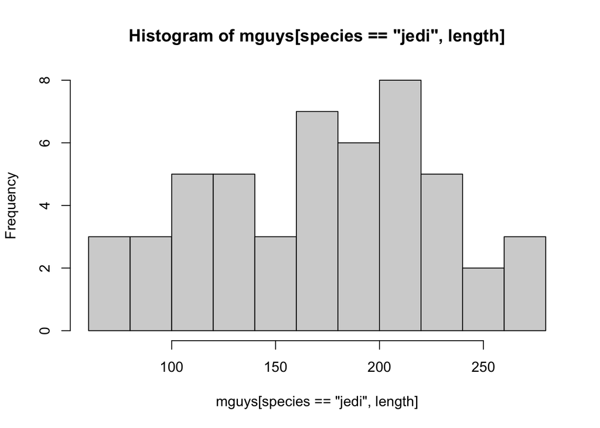

```r
# Load libraries
require(ggplot2)
require(cowplot)

# Set breaks
breaks = 10

# Plot hist using base R
hist(mguys[species == "jedi", length], breaks = breaks)
```

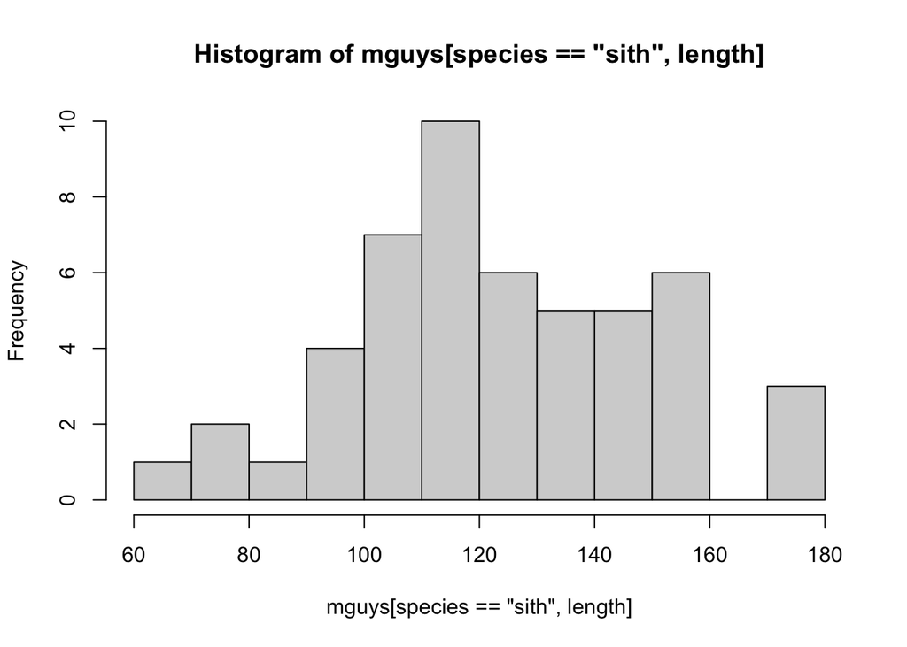

```r
hist(mguys[species == "sith", length], breaks = breaks)
```

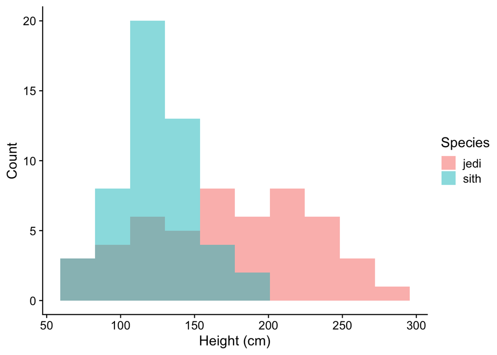

```r
# Plot with ggplot2
theme_set(theme_cowplot()) # Set theme

# Plot
plt_hist = ggplot(mguys, aes(x = length, fill = species)) +
  geom_histogram(position = "identity", alpha = 0.5, bins = breaks) +
  labs(y = "Count", x = "Height (cm)", fill = "Species")
plt_hist
```

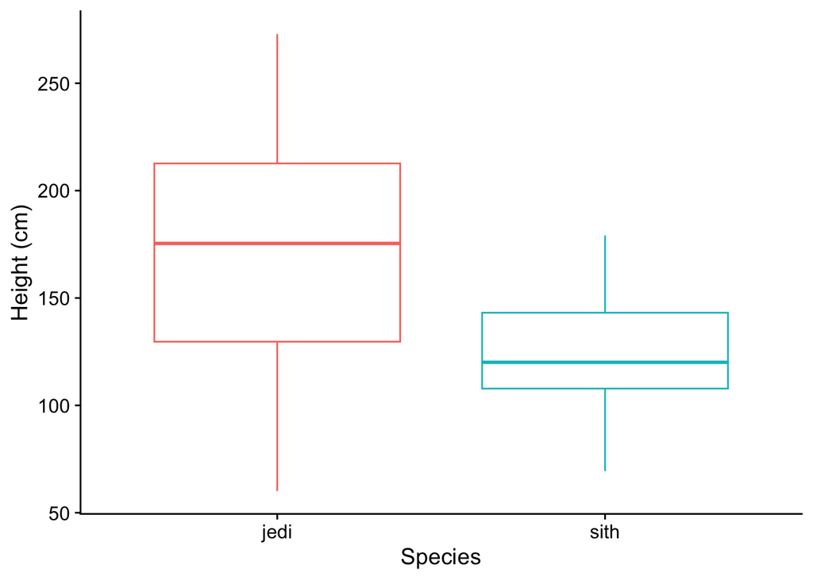

```r
# Plot boxplots
plt_box = ggplot(mguys, aes(x = species, y = length, color = species)) +
  geom_boxplot() +
  labs(y = "Height (cm)", x = "Species") +
  theme(legend.position = "none")
plt_box
```

```r
# Save the histograms
ggsave("~/Documents/KI-UT_Course/plots/assignment_1/height_hist_plot.png", plot = plt_hist) #png for quick saving and sharing
ggsave("~/Documents/KI-UT_Course/plots/assignment_1/height_hist_plot.pdf", plot = plt_hist) #pdf to keep resolution
ggsave("~/Documents/KI-UT_Course/plots/assignment_1/height_hist_plot.svg", plot = plt_hist) #svg to be able to make changes in illustrator etc for publications

# Save the boxplots
ggsave("~/Documents/KI-UT_Course/plots/assignment_1/height_boxplot.png", plot = plt_box) #png for quick saving and sharing
ggsave("~/Documents/KI-UT_Course/plots/assignment_1/height_boxplot.pdf", plot = plt_box) #pdf to keep resolution
ggsave("~/Documents/KI-UT_Course/plots/assignment_1/height_boxplot.svg", plot = plt_box) #svg to be able to make changes in illustrator etc for publications
```

2. Load the gene expression data matrix from the ‘microarray_data.tab’ dataset provided in the shared folder, it is a big tabular separated matrix.

```r
array = fread("~/Downloads/microarray_data.tab")
```

```
a) How big is the matrix in terms of rows and columns?
b) Count the missing values per gene and visualize this result.
c) Find the genes for which there are more than X% (X=10%, 20%, 50%)
```

missing values. d) Replace the missing values by the average expression value for the particular gene. (Note: Imputing data has to be used with caution!)

```r
# To get the dimensions of the microarray
dim(array)
```

```
## [1]  553 1000
```

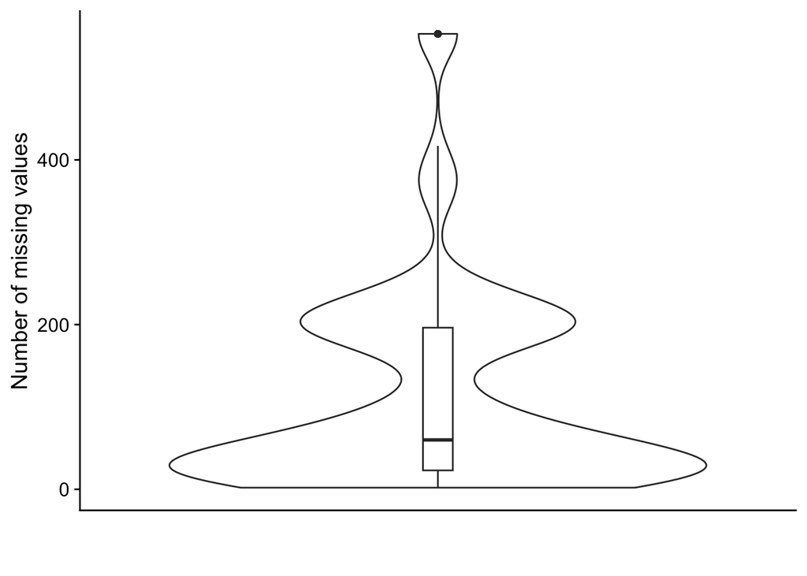

```r
# Calculate missing values per gene
missing = data.table(gene = colnames(array), n_missing = colSums(is.na(array)))

# Plot number of missing values per gene
ggplot(missing, aes(x = "", y = n_missing)) +
  geom_violin() +
  geom_boxplot(width = .05) +
  labs(y = "Number of missing values", x = "") +
  theme(axis.ticks.x = element_blank())
```

```r
# Find genes where more than X% are missing values
missing[, fraction := n_missing / nrow(array)]
miss_10 = missing[fraction > .1, gene]
miss_20 = missing[fraction > .2, gene]
miss_50 = missing[fraction > .5, gene]

# Impute values for missing data
imputed_array = apply(array, 2, function(x) {
  avg = mean(x, na.rm = T)
  nafill(x, fill = avg)
})
```

3. Visualize the data in the CO2 dataset in a way that gives you a deeper understanding of the data. What do you see?

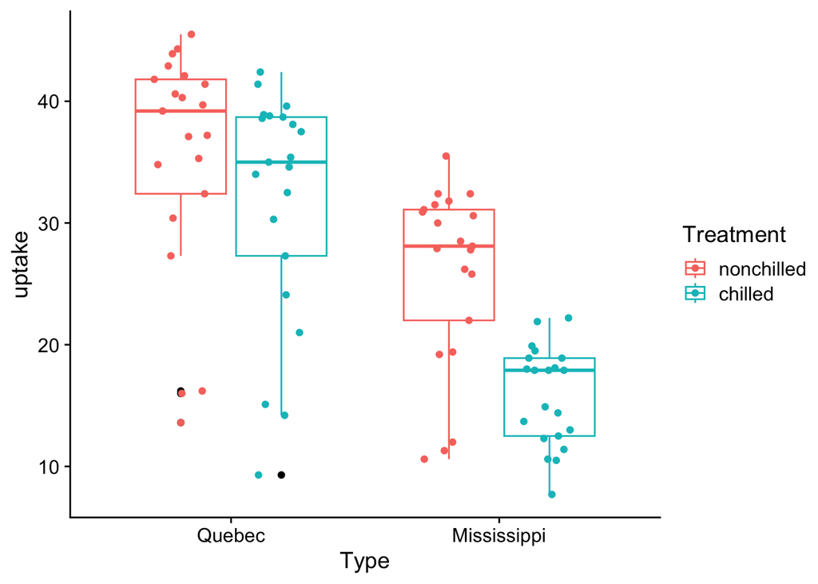

```r
# Load libraries
require(ggpubr)

# Set DT
CO2 = CO2
setDT(CO2)

# Plot uptake
ggplot(CO2, aes(x = Type, y = uptake, color = Treatment)) +
  geom_boxplot(outlier.colour = "black") +
  geom_point(position = position_jitterdodge())
```

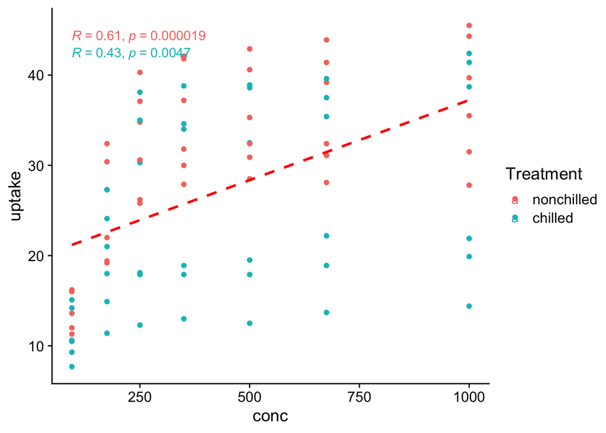

```r
# Plot uptake vs ambient CO2 concentration
ggplot(CO2, aes(x = conc, y = uptake, color = Treatment)) +
  geom_point() +
  stat_cor() +
  geom_smooth(method = "lm", se = FALSE, col = "red", linetype = 2)
```

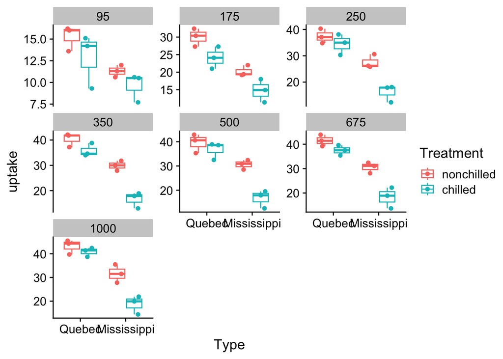

```r
# Plot uptake
ggplot(CO2, aes(x = Type, y = uptake, color = Treatment)) +
  geom_boxplot() +
  geom_point(position = position_jitterdodge()) +
  facet_wrap(~conc, scales = "free_y")
```

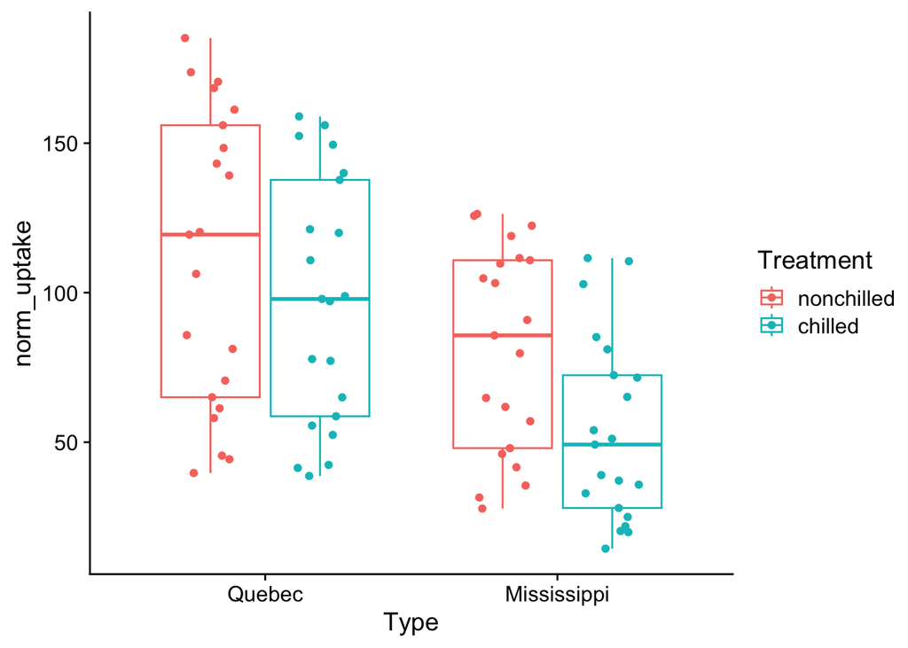

```r
# Normalizing linearly by concentration is not the best but will do so anyway..

# Normalize for ambient CO2 concentration
CO2[, norm_uptake := uptake / conc * 1000]

# Plot norm uptake
ggplot(CO2, aes(x = Type, y = norm_uptake, color = Treatment)) +
  geom_boxplot(outlier.colour = "black") +
  geom_point(position = position_jitterdodge())
```

I see that Mississippi has a low overal uptake compared to Quebec, even when accounting for the CO2 concentration. Furthermore, Chilled treatment results in a low overal uptake compared to nonchilled treatment.

## Task 8 - Tidybiology

1. Install the Tidybiology package, which includes the data ‘chromosome’ and ‘proteins’ devtools::install_github(“hirscheylab/tidybiology”)
1. Extract summary statistics (mean, median and maximum) for the following variables from the ‘chromosome’ data: variations, protein coding genes, and miRNAs. Utilize the tidyverse functions to make this as simply as possible.
2. How does the chromosome size distribute? Plot a graph that helps to visualize this by using ggplot2 package functions.
3. Does the number of protein coding genes or miRNAs correlate with the length of the chromosome? Make two separate plots to visualize these relationships.
4. Calculate the same summary statistics for the ‘proteins’ data variables length and mass. Create a meaningful visualization of the relationship between these two variables by utilizing the ggplot2 package functions. Play with the colors, theme- and other visualization parameters to create a plot that pleases you.

```r
# Load libraries
require(tidybiology)
require(scales)
require(patchwork)

# Load data and setDT
data(chromosome)
setDT(chromosome)

# Get summary for variations, protein coding genes and miRNAs
summary(chromosome[, .(variations, protein_codinggenes, mi_rna)])
```

```
##    variations       protein_codinggenes     mi_rna
##  Min.   :  211643   Min.   :  71.0      Min.   : 15.00
##  1st Qu.: 4395298   1st Qu.: 595.8      1st Qu.: 55.75
##  Median : 6172346   Median : 836.0      Median : 75.00
##  Mean   : 6484572   Mean   : 850.0      Mean   : 73.17
##  3rd Qu.: 8742592   3rd Qu.:1055.5      3rd Qu.: 92.00
##  Max.   :12945965   Max.   :2058.0      Max.   :134.00
```

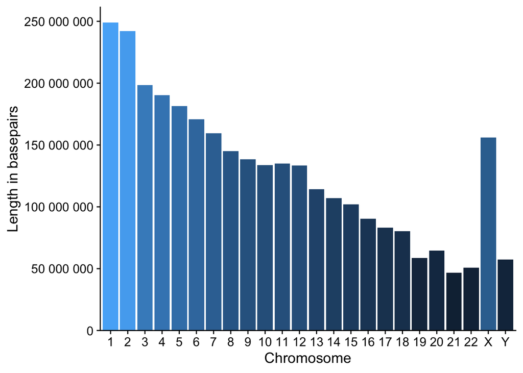

```r
# Plot chromosome sizes
ggplot(chromosome, aes(x = id, y = basepairs, fill = basepairs)) +
  geom_col() +
  labs(y = "Length in basepairs", x = "Chromosome") +
  scale_y_continuous(expand = expansion(mult = c(0, .05)),
                     labels = scales::number_format()) +
  theme(legend.position = "none")
```

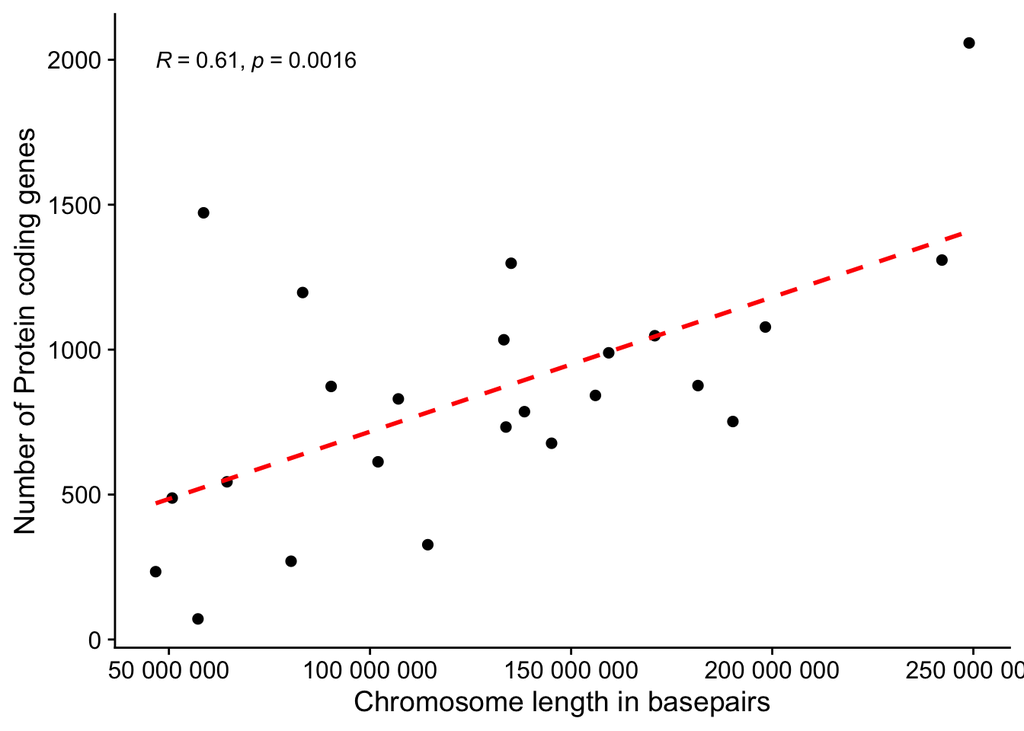

```r
# Plot chromosome length vs number of protein coding genes
ggplot(chromosome, aes(x = basepairs, y = protein_codinggenes)) +
  geom_point(size = 2) +
  stat_cor() +
  labs(y = "Number of Protein coding genes", x = "Chromosome length in basepairs") +
  geom_smooth(method = "lm", se = FALSE, linetype = 2, color = "red") +
  scale_x_continuous(labels = number_format())
```

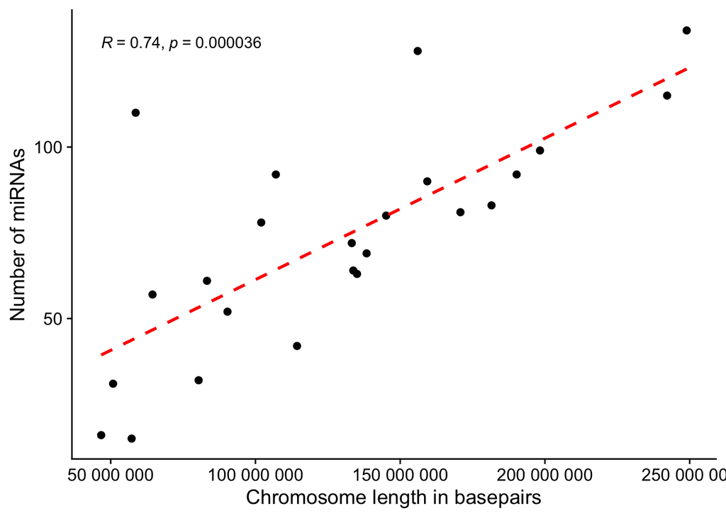

```r
ggplot(chromosome, aes(x = basepairs, y = mi_rna)) +
  geom_point(size = 2) +
  stat_cor() +
  labs(y = "Number of miRNAs", x = "Chromosome length in basepairs") +
  geom_smooth(method = "lm", se = FALSE, linetype = 2, color = "red") +
  scale_x_continuous(labels = number_format())
```

```r
# Yes the chromosome length does correlate with the number of protein coding genes and miRNAs

# Get summary for protein length and mass
data(proteins)
setDT(proteins)
summary(proteins[, .(length, mass)])
```

```
##      length             mass
##  Min.   :    2.0   Min.   :    260
##  1st Qu.:  251.0   1st Qu.:  27940
##  Median :  414.0   Median :  46140
##  Mean   :  557.2   Mean   :  62061
##  3rd Qu.:  669.0   3rd Qu.:  74755
##  Max.   :34350.0   Max.   :3816030
```

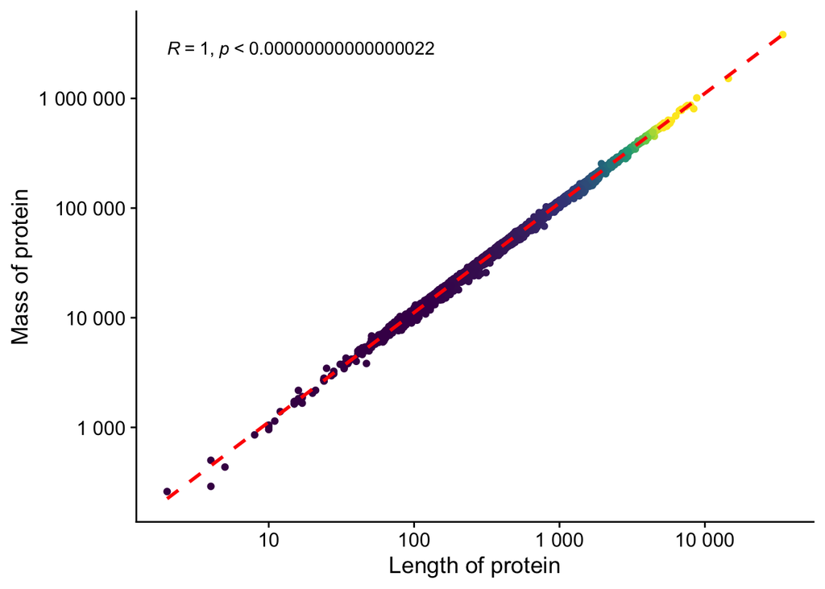

```r
# Plot length vs mass
ggplot(proteins, aes(x = length, y = mass, color = length)) +
  geom_point() +
  labs(y = "Mass of protein", x = "Length of protein") +
  scale_y_log10(labels = number_format()) +
  scale_x_log10(labels = number_format()) +
  stat_cor() +
  geom_smooth(method = "lm", se = FALSE, linetype = 2, color = "red") +
  scale_color_viridis_c(oob = squish, limits = c(0, 5000)) +
  theme(legend.position = "none")
```